# An introduction to mbkmeans

[mbkmeans](https://www.bioconductor.org/packages/release/bioc/vignettes/mbkmeans/inst/doc/Vignette.html)

# Introduction

This vignette provides an introductory example on how to work with the mbkmeans package, which contains an implementation of the mini-batch k-means algorithm proposed in (Sculley 2010) for large single-cell sequencing data. This algorithm runs the _k_means iterations on small, random subsamples of data (``mini batches’’) rather than the entire dataset. This both speeds up computation and reduces the amount of data that must be contained in memory.

The main function to be used by the users is mbkmeans. This is implemented as an S4 generic and methods are implemented for matrix, Matrix, HDF5Matrix, DelayedMatrix, SummarizedExperiment, and SingleCellExperiment.

Most of this work was inspired by the MiniBatchKmeans() function implemented in the ClusterR R package and we re-use many of the C++ functions implemented there.

Our main contribution here is to provide an interface to the DelayedArray and HDF5Array packages so that mbkmeans algorithm only brings into memory at any time the “mini-batches” needed for the current iteration, and never requires loading the entire dataset into memory. This allows the user to run the mini-batch k-means algorithm on very large datasets that do not fit entirely in memory. mbkmeans also runs seamlessly on in-memory matrices provided by the user, and doing so significantly increases the speed of the algorithm compared to the standard k-means algorithm ((Hicks et al. 2020)). A complete comparison of mbkmeans with other implementations can be found in (Hicks et al. 2020).

The motivation for this work is the clustering of large single-cell RNA-sequencing (scRNA-seq) datasets, and hence the main focus is on Bioconductor’s SingleCellExperimentand SummarizedExperiment data container. For this reason, mbkmeans assumes a data representation typical of genomic data, in which genes (variables) are in the rows and cells (observations) are in the column. This is contrary to most other statistical applications, and notably to the stats::kmeans() and ClusterR::MiniBatchKmeans() functions that assume observations in rows.

We provide a lower-level mini_batch() function that expects observations in rows and is expected to be a direct replacement of ClusterR::MiniBatchKmeans() for on-disk data representations such as HDF5 files. The rest of this document shows the typical use case through the mbkmeans() interface; users interested in the mini_batch() function should refer to its manual page.

## Example dataset

To illustrate a typical use case, we use the pbmc4k dataset of the TENxPBMCData package. This dataset contains a set of about 4,000 cells from peripheral blood from a healthy donor and is expected to contain many types or clusters of cell.

We would note that mbkmeans is designed for very large datasets, in particular for datasets large enough that either the full data matrix can’t be held in memory, or the computations necessary cannot be computed. This vignette works with a small dataset to allow the user to quickly follow along and understand the commands. (Hicks et al. 2020) shows the example of using mbkmeans with a dataset with 1.3 million cells, which is a more appropriate size for observing improved memory usage and improved speed.

First, we load the needed packages.

```r
library(TENxPBMCData)
library(scater)
library(SingleCellExperiment)
library(mbkmeans)
library(DelayedMatrixStats)
```

Note that in this vignette, we do not aim at identifying biologically meaningful clusters (that would entail a more sophisticated normalization of data and dimensionality reduction), but instead we only aim to show how to run mini-batch k-means on a HDF5-backed matrix.

We normalize the data simply by scaling for the total number of counts using scater and select the 1,000 most variable genes and a random set of 100 cells to speed-up computations.

```r
tenx_pbmc4k <- TENxPBMCData(dataset = "pbmc4k")
```

```
snapshotDate(): 2020-10-02
see ?TENxPBMCData and browseVignettes('TENxPBMCData') for documentation
loading from cache
```

```r
set.seed(1034)
idx <- sample(seq_len(NCOL(tenx_pbmc4k)), 100)
sce <- tenx_pbmc4k[, idx]
#normalization
sce <- logNormCounts(sce)
vars <- rowVars(logcounts(sce))
names(vars) <- rownames(sce)
vars <- sort(vars, decreasing = TRUE)
sce1000 <- sce[names(vars)[1:1000],]
sce1000
```

```
class: SingleCellExperiment
dim: 1000 100
metadata(0):
assays(2): counts logcounts
rownames(1000): ENSG00000090382 ENSG00000204287 ... ENSG00000117748
  ENSG00000135968
rowData names(3): ENSEMBL_ID Symbol_TENx Symbol
colnames: NULL
colData names(12): Sample Barcode ... Date_published sizeFactor
reducedDimNames(0):
altExpNames(0):
```

# mbkmeans

The main function, mbkmeans(), returns a list object including centroids, WCSS_per_cluster (where WCSS stands for within-cluster-sum-of-squares), best_initialization, iters_per_initiazation and Clusters.

It takes any matrix-like object as input, such as SummarizedExperiment, SingleCellExperiment, matrix, DelayedMatrix and HDF5Matrix.

In this example, the input is a SingleCellExperiment object.

```r
res <- mbkmeans(sce1000, clusters = 5,
                reduceMethod = NA,
                whichAssay = "logcounts")
```

The number of clusters (such as k in the k-means algorithm) is set through the clusters argument. In this case, we set clusters = 5 for no particular reason. For SingleCellExperiment objects, the function provides the reduceMethod and whichAssay arguments. The reduceMethod argument should specify the dimensionality reduction slot to use for the clustering, and the default is “PCA”. Note that this does not perform PCA but only looks at a slot called “PCA” already stored in the object. Alternatively, one can specify whichAssay as the assay to use as input to mini-batch k-means. This is used only when reduceMethod option is NA. See ?mbkmeans for more details.

## Choice of arguments

There are additional arguements in mbkmeans() that make the function more flexible and suitable for more situations.

### Batch size

he size of the mini batches is set through the batch_size argument. This argument gives the size of the samples of data brought into memory at any one time, and thus constrains the memory usage of the alogrithm.

The blocksize() function can be used to set the batch size to the maximum allowed by the available memory. It considers both the number of columns in the dataset and the amount of RAM on the current matchine to calculate as large of a batch size as reasonable for the RAM available to the session. The calculation uses get_ram() function in benchmarkme package. See the benchmarkme vignette for more details.

```r
batchsize <- blocksize(sce1000)
```

```
     Unable to detect your RAM. # nocov
            Please raise an issue at https://github.com/csgillespie/benchmarkme
Unable to determine available RAM. Setting it to 1GB.
```

```r
batchsize
```

```
[1] 100
```

In this simple example, because the whole data fits in memory, the default batch size would be a single batch of size 100.

(Hicks et al. 2020) provides a comparison of the effect of batch size for large datasets (i.e. where the full data cannot be stored in memory). Their results show the algorithm to be robust to a large range of batch sizes (1,000-10,000 cells): accuracy of the results were equivalent if the batch size was above 500-1000 cells, with no noticable advantage in memory usage or speed as long as the batches were smaller than roughly 10,000 cells (corresponding to a subsample of the full data matrix whose memory foot print is not noticeable on most modern computers). For this reason, we would err on the larger range of batch size suggested in (Hicks et al. 2020) – 10,000 cells. Furthermore, since the initialization uses by default the same number of cells as batch size, this gives a robust sample for determining the initial start point.

We would note that it is better to make choices on batch size based on choosing the absolute number of cells in a batch rather than choosing batch size based on a percentage of the overall sample size. If batch size is chosen based on the percentage of cells, very large datasets will use very large batches of cells, negating the memory and speed gains. Moreover such large batches are not needed for good performance of the algorithm. The continual resampling of the batches works like stochastic gradient descent and allows for (local) minimization of the objective function (Sculley 2010) with relatively small batch sizes, as demonstrated on single-cell data in the work of (Hicks et al. 2020). If anything, the size of the batch should be governed more by the complexity of the problem (e.g. the number of underlying true clusters or subtypes), rather than the number of overall cells in the dataset.

### Initialization

The performance of mini-batch k-means greatly depends on the process of initialization. We implemented two different initialization methods:

1. Random initialization, as in regular k-means;
2. kmeans++, as proposed in (Arthur and Vassilvitskii 2007). The default is kmeans++.

The percentage of data to use for the initialization centroids is set through the init_fraction argument, which should be larger than 0 and less than 1. The default value is given so that the proportion matches the value of batch_size, converted to a proportion of the data.

```r
res_random <- mbkmeans(sce1000, clusters = 5,
                reduceMethod = NA,
                whichAssay = "logcounts",
                initializer = "random")
table(res$Clusters, res_random$Clusters)
```

```
     1  2  3  4  5
  1  0  0  0  0  1
  2  7 12  0  2  0
  3  9  0 41  0  0
  4  0  0  0  0 27
  5  0  0  1  0  0
```

Note that large values of init_fraction will result in that proportion of the data being held in memory and used in the initialization of the kmeans++ algorithm. Therefore, large values of init_fraction will require a great deal of memory – potentially more than that used by the actual clustering algorithm. Indeed keeping the fraction used constant for larger and larger datasets will result in commiserate numbers of cells being used in the initialization and increasing the memory usage (similar to the issues discussed above for batch size). Therefore, we recommend that users keep the default and make changes to the batch_size parameter as desired, ensuring consistent memory usage across both the initialization stage and the actual clustering stage of the algorithm. As mentioned in the discussion above on batch_size, for this reason we would recommend batch_size on the larger range suggested as reasonable in (Hicks et al. 2020) so as to improve the initialization.

## Running mbkmeans with multiple values of k

The main parameter to set in k-means and its variants is the number of clusters k. mbkmeans is quick enough to rerun the clustering algorithm with different number of clusters even in very large datasets.

Here, we apply mbkmeans with k from 5 to 15 and select the number of clusters using the elbow method (i.e., the value that corresponds to the point of inflection on the curve). We note that this is just a rule of thumb for selecting the number of clusters, and many different methods exist to decide the appropriate value of k.

To speed up the computations, we will cluster on the top 20 PCs.

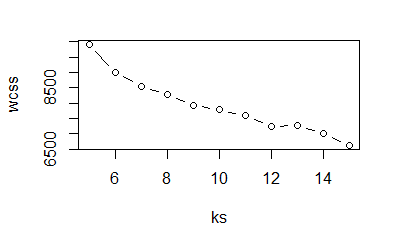

```r
sce1000 <- runPCA(sce1000, ncomponents=20)
ks <- seq(5, 15)
res <- lapply(ks, function(k) {
    mbkmeans(sce1000, clusters = k,
             reduceMethod = "PCA",
             calc_wcss = TRUE, num_init=10)
})
wcss <- sapply(res, function(x) sum(x$WCSS_per_cluster))
plot(ks, wcss, type = "b")
```

From the plot, it seems that k = 12 could be a reasonable value.

# Comparison with k-means

Note that if we set init_fraction = 1, initializer = “random”, and batch_size = ncol(x), we recover the classic k-means algorithm.

```r
res_full <- mbkmeans(sce1000, clusters = 5,
                     reduceMethod = NA,
                     whichAssay = "logcounts",
                     initializer = "random",
                     batch_size = ncol(sce1000))
res_classic <- kmeans(t(logcounts(sce1000)),
                      centers = 5)
table(res_full$Clusters, res_classic$cluster)
```

```
     1  2  3  4  5
  1 28  0  0  0  0
  2  0  0  0  0 14
  3  0  7  6  0  0
  4  0  0  0  1  0
  5  0  0  9 35  0
```

Note however, that since the two algorithms start from different random initializations, they will not always converge to the same solution. Furthremore, if the algorithm uses batches smaller than the full dataset (batch_size<ncol(x)), then mbkmeans will not converge to the same result as kmeans even with the same initialization. This is due to the fact that kmeans and mbkmeans have different search paths for an optimum and the problem is non-convex.

For a comparison of memory usage, speed, and accuracy of mbkmeans with kmeans for the non-trivial case where the algorithm uses batches, see (Hicks et al. 2020), where it is demonstrated that mbkmeans provides significant speed improvements and uses less memory than kmeans, without loss of accuracy.

# Use with bluster

The bluster package provides a flexible and extensible framework for clustering in Bioconductor packages/workflows. The clusterRows() function controls dispatch to different clustering algorithms. In this case, we will use the mini-batch k-means algorithm to cluster cells into cell populations based on their principal component analysis (PCA) coordinates.

```r
mat <- reducedDim(sce1000, "PCA")
dim(mat)
```

```
[1] 100  20
```

In the following three scenarios, we pass the number of cluster centers as a number using the centers=5 argument. In addition, we can also pass other mbkmeans arguments (e.g. batch_size=10). In the first two cases, we only return the cluster labels. However, in the third scenario, we ask for the full mbkmeans output.

```r
clusterRows(mat, MbkmeansParam(centers=5))
```

```
  [1] 1 1 5 3 5 5 3 4 4 3 5 2 1 4 4
 [16] 4 3 5 4 3 1 4 5 5 4 3 4 4 5 4
 [31] 3 5 1 4 2 4 1 5 5 5 5 5 5 5 5
 [46] 3 4 3 1 5 5 2 4 3 2 5 1 4 1 3
 [61] 5 5 4 4 3 5 1 1 5 5 4 5 5 4 5
 [76] 3 4 5 3 4 1 4 5 4 2 5 1 5 4 4
 [91] 5 4 1 1 5 5 2 5 4 2
Levels: 1 2 3 4 5
```

```r
clusterRows(mat, MbkmeansParam(centers=5, batch_size=10))
```

```
  [1] 3 3 3 2 3 3 2 4 5 2 3 1 3 4 4
 [16] 4 2 3 4 2 3 4 3 3 4 2 4 5 3 4
 [31] 2 3 3 4 1 4 3 3 3 3 3 3 3 3 3
 [46] 2 5 2 3 3 3 1 5 2 1 3 3 5 3 2
 [61] 3 3 4 5 2 3 3 3 3 3 4 3 3 4 3
 [76] 2 5 3 2 4 3 5 3 4 1 3 3 3 4 5
 [91] 3 4 3 3 3 3 3 3 5 1
Levels: 1 2 3 4 5
```

```r
clusterRows(mat, MbkmeansParam(centers=5, batch_size=10), full = TRUE)
```

```
$clusters
  [1] 4 4 2 3 2 2 3 5 5 3 2 1 4 5 5
 [16] 5 3 2 5 3 4 5 2 2 5 3 5 5 2 5
 [31] 3 2 2 5 1 5 4 2 2 2 2 2 2 2 2
 [46] 3 5 3 4 2 2 1 5 3 1 2 2 5 2 3
 [61] 2 2 5 5 3 2 4 2 2 2 5 2 2 5 2
 [76] 3 5 2 3 5 4 5 2 5 1 2 4 2 5 5
 [91] 2 5 4 4 2 2 4 2 5 4
Levels: 1 2 3 4 5

$objects
$objects$centroids
           [,1]       [,2]
[1,] -0.4577116 17.6859771
[2,] -7.3532260 -2.2780222
```

[output cut: 76 more lines]

While many of the times clustering will be performed on in-memory data (for example after PCA), the clusterRows function also accepts any matrix-like object (in-memory or on-disk data representation) that mbkmeans accepts.

For example, we can cluster using mbkmeans on the logcounts assay in the sce1000 object (similar to above), which is a DelayedMatrix object from the DelayedArray package.

Note: We transpose the matrix as the clusterRows function expects observations along the rows and variables along the columns.

```r
logcounts(sce1000)
```

```
<1000 x 100> matrix of class DelayedMatrix and type "double":
                     [,1]      [,2]
ENSG00000090382  0.000000  1.482992
ENSG00000204287  2.198815  0.000000
ENSG00000163220  1.762993  1.482992
ENSG00000143546  0.000000  1.135438
ENSG00000019582  3.402730  1.762861
            ...         .         .
ENSG00000145779 0.0000000 0.6766523
ENSG00000106948 0.0000000 1.1354382
ENSG00000155660 0.0000000 0.6766523
ENSG00000117748 0.0000000 0.0000000
ENSG00000135968 0.0000000 0.0000000
                     [,3] ...
ENSG00000090382  0.000000   .
ENSG00000204287  0.000000   .
ENSG00000163220  0.000000   .
ENSG00000143546  1.113099   .
ENSG00000019582  1.733874   .
            ...         .   .
ENSG00000145779 0.0000000   .
ENSG00000106948 0.0000000   .
ENSG00000155660 0.0000000   .
ENSG00000117748 0.0000000   .
ENSG00000135968 0.0000000   .
                    [,99]    [,100]
ENSG00000090382 5.4330604 0.0000000
ENSG00000204287 5.3387971 0.0000000
ENSG00000163220 2.1176311 2.0642508
ENSG00000143546 0.3825221 0.0000000
ENSG00000019582 6.2009459 2.0642508
            ...         .         .
ENSG00000145779 0.9342195 0.0000000
ENSG00000106948 0.9342195 1.3735556
ENSG00000155660 0.3825221 1.3735556
ENSG00000117748 0.0000000 0.0000000
ENSG00000135968 0.3825221 0.0000000
```

```r
clusterRows(t(logcounts(sce1000)), MbkmeansParam(centers=4))
```

```
  [1] 4 4 4 3 4 4 3 2 2 3 4 4 4 2 2
 [16] 2 3 4 2 3 4 2 4 4 2 3 2 2 4 2
 [31] 3 4 4 2 4 2 4 4 4 4 4 4 4 4 4
 [46] 3 2 3 4 4 4 4 2 3 4 4 4 2 4 3
 [61] 4 4 2 2 3 4 4 4 1 4 2 4 4 2 4
 [76] 3 2 4 3 2 4 2 4 2 4 4 4 4 2 2
 [91] 4 2 4 4 4 4 4 4 2 4
Levels: 1 2 3 4
```